# Processing HWSD in R to generate global maps

K Todd-Brown (ktoddbrown@gmail.com)

March 12, 2015

Soil carbon values extracted from the Harmonized World Soil Database are at too fine a resolution to work with for most global analysis. This repository goes through and regrids the soil organic carbon and bulk density maps from the HWSD to a 1x1 degree resolution using R. An additional regridded version of HWSD can be found http://daac.ornl.gov/SOILS/guides/HWSD.html (unrelated to this repo) and there is a R package that can be found here https://github.com/dlebauer/rhwsd (also unrelated to this repo).

This work was based off of Rossiter, D. G. (2012). Processing the Harmonized World Soil Database (Version 1.2) in R. Institute of Soil Science, Chinese Academy of Sciences.

Date can be downloaded http://webarchive.iiasa.ac.at/Research/LUC/External-World-soil-database/HTML/ and will need to be converted from the Mircosoft Access (mdb) format it is orginally delivered in to a SQL (sqlite) format using MDBExplorer, MDBLite or something similar.

First let’s set up the libraries.

```r
library(compiler) ##pre-compile library to make some functions faster
library(raster)   ##Deal with spatial maps nicely
library(RSQLite)  ##Load the atribute database
source('R/lookUp.R')
```

First read in the raster that gives the soil identifier for each grid point.

```r
##Load the raster
hwsd <- raster("HWSD_vs1_21/HWSD_RASTER/hwsd.bil") #1.87 GB or HWSD_RASTER.zip MB
(proj4string(hwsd) <- "+proj=longlat +datum=WGS84 +ellps=WGS84 +towgs84=0,0,0")
```

```
## [1] "+proj=longlat +datum=WGS84 +ellps=WGS84 +towgs84=0,0,0"
```

```r
newproj <- "+proj=longlat +datum=WGS84 +ellps=WGS84 +towgs84=0,0,0"
```

Next read in the soil carbon attributes of all soil identifies.

```r
cat(format(Sys.time(), '%H:%M:%OS3'), 'starting load attributes...\n')
```

```
## 16:19:44.586 starting load attributes...
```

```r
##Load the atribute database
m <- dbDriver("SQLite")
##HWSD.sqlite created from .mdb using MDB Explorer
##...load into database
con <- dbConnect(m, dbname = "HWSD_vs1_21/HWSD.sqlite") #10.6 MB

##Inform the user of what we have
cat('List of available tables:\n')
```

```
## List of available tables:
```

```r
print(dbListTables(con)) ##list the tables
```

```
##  [1] "D_ADD_PROP"       "D_AWC"            "D_COVERAGE"
##  [4] "D_DRAINAGE"       "D_IL"             "D_ISSOIL"
##  [7] "D_PHASE"          "D_ROOTS"          "D_SWR"
## [10] "D_SYMBOL"         "D_SYMBOL74"       "D_SYMBOL85"
## [13] "D_SYMBOL90"       "D_TEXTURE"        "D_USDA_TEX_CLASS"
## [16] "HWSD_DATA"        "HWSD_SMU"
```

```r
cat('HWSD_DATA table structure\n')
```

```
## HWSD_DATA table structure
```

```r
print(dbGetQuery(con, "pragma table_info(HWSD_DATA)")$name)
```

```
##  [1] "ID"                 "MU_GLOBAL"          "MU_SOURCE1"
##  [4] "MU_SOURCE2"         "ISSOIL"             "SHARE"
##  [7] "SEQ"                "SU_SYM74"           "SU_CODE74"
## [10] "SU_SYM85"           "SU_CODE85"          "SU_SYM90"
## [13] "SU_CODE90"          "T_TEXTURE"          "DRAINAGE"
## [16] "REF_DEPTH"          "AWC_CLASS"          "PHASE1"
## [19] "PHASE2"             "ROOTS"              "IL"
## [22] "SWR"                "ADD_PROP"           "T_GRAVEL"
## [25] "T_SAND"             "T_SILT"             "T_CLAY"
## [28] "T_USDA_TEX_CLASS"   "T_REF_BULK_DENSITY" "T_OC"
## [31] "T_PH_H2O"           "T_CEC_CLAY"         "T_CEC_SOIL"
## [34] "T_BS"               "T_TEB"              "T_CACO3"
## [37] "T_CASO4"            "T_ESP"              "T_ECE"
## [40] "S_GRAVEL"           "S_SAND"             "S_SILT"
## [43] "S_CLAY"             "S_USDA_TEX_CLASS"   "S_REF_BULK_DENSITY"
## [46] "S_OC"               "S_PH_H2O"           "S_CEC_CLAY"
## [49] "S_CEC_SOIL"         "S_BS"               "S_TEB"
## [52] "S_CACO3"            "S_CASO4"            "S_ESP"
## [55] "S_ECE"              "T_BULK_DENSITY"     "S_BULK_DENSITY"
```

```r
##What entries we are interested in from the HWSD_DATA
##...pull for the density and OC info
colNames.data <- c('ID', 'MU_GLOBAL', 'ISSOIL',  'REF_DEPTH',
                   'T_REF_BULK_DENSITY', 'S_REF_BULK_DENSITY',
                   'T_BULK_DENSITY', 'S_BULK_DENSITY',
                   'T_OC', 'S_OC', 'SHARE')
##What entries we are interested in from the HWSD_SMU
##...pull so we can see what type of soil are have
colNames.smu <- c('ID', 'MU_GLOBAL', 'SU_SYMBOL', 'SU_CODE')

##Pull the tables we are interested in
dataTable <- dbGetQuery(con, paste("select", paste(colNames.data, collapse = ", "), "from HWSD_DATA"))
smu.table <- dbGetQuery(con, paste("select", paste(colNames.smu, collapse = ", "), "from HWSD_SMU"))

cat('process dataTable:', format(Sys.time(), '%H:%M:%OS3'), '...')
```

```
## process dataTable: 16:19:44.816 ...
```

```r
vapplyWrapper <- cmpfun(function (soilID){
  return(vapply(soilID, FUN=function(x){c(x, lookUp(x))},
                FUN.VALUE=rep(0, times=3), USE.NAMES=FALSE))}) ##streight up complied vapply, this is the one used

shortDataTable <- vapplyWrapper(unique(dataTable$MU_GLOBAL))

shortDataTable  <- data.frame(t(shortDataTable))
names(shortDataTable) <- c('MU', 'bulk', 'soc')
shortDataTable <- rbind(c(0, rep(NA, length=2)), shortDataTable)
shortDataTable <- rbind(rep(NA, length=3), shortDataTable)
cat(format(Sys.time(), '%H:%M:%OS3'), 'done\n')
```

```
## 16:23:07.044 done
```

Then process the raster in chuncks to connect the identifier to bulk density and soil organic carbon.

```r
bd_file <- 'outputs/fullBulkDensity.grd'
soc_file <- 'outputs/fullSOC.grd'

bulk <- raster(hwsd)
soc <- raster(hwsd)

bulk <- writeStart(bulk, file=bd_file, overwrite=TRUE)
soc <- writeStart(soc, file=soc_file, overwrite=TRUE)

cat(format(Sys.time(), '%H:%M:%OS3'), 'starting to create maps...\n')
```

```
## 15:56:51.473 starting to create maps...
```

```r
bs <- blockSize(hwsd)
#cat('going through', bs$n, 'blocks\n')
for(ii in 1:bs$n){
  if(ii %% 10 == 0){
    #cat(ii, '\n')
    }else{
      #cat('.')
      }
  soilIndex <- getValues(hwsd, row=bs$row[ii], nrows=bs$nrows[ii])
  soilInfo <- shortDataTable[match(as.vector(soilIndex), shortDataTable$MU),]

  bulk <- writeValues(bulk, soilInfo$bulk, bs$row[ii])
  soc <- writeValues(soc, soilInfo$soc, bs$row[ii])
  }

writeStop(bulk)
```

```
## class       : RasterLayer
## dimensions  : 21600, 43200, 933120000  (nrow, ncol, ncell)
## resolution  : 0.008333333, 0.008333333  (x, y)
## extent      : -180, 180, -90, 90  (xmin, xmax, ymin, ymax)
## coord. ref. : +proj=longlat +datum=WGS84 +ellps=WGS84 +towgs84=0,0,0
## data source : /Users/todd528/Documents/CurrentProjects/RHWSD/outputs/fullBulkDensity.grd
## names       : layer
## values      : 0, 1776  (min, max)
```

```r
writeStop(soc)
```

```
## class       : RasterLayer
## dimensions  : 21600, 43200, 933120000  (nrow, ncol, ncell)
## resolution  : 0.008333333, 0.008333333  (x, y)
## extent      : -180, 180, -90, 90  (xmin, xmax, ymin, ymax)
## coord. ref. : +proj=longlat +datum=WGS84 +ellps=WGS84 +towgs84=0,0,0
## data source : /Users/todd528/Documents/CurrentProjects/RHWSD/outputs/fullSOC.grd
## names       : layer
## values      : 0, 118.7298  (min, max)
```

```r
cat(format(Sys.time(), '%H:%M:%OS3'), 'done\n')
```

```
## 16:14:00.404 done
```

Finally, regrid everything to a 1x1 degree grid cell via area averaging. Note that there are several ways to do this regridding and no real agreed upon method. However using a interpolation method to cross several orders of magnitude in grid size is generally not recommended. An alternate method might include aggregating the grid cell before assigning the bulk densith and soil organic carbon by assigning the dominate soil identifier to each new grid cell. You are encouraged to use your best scientific judgement in this matter.

```r
bulk <- raster(bd_file)
soc <- raster(soc_file)

bulk.regrid <- aggregate(bulk, fact=120, fun=mean, filename='outputs/bulk_area1deg.grd')
soc.regrid <- aggregate(soc, fact=120, fun=mean, filename='outputs/soc_area1deg.grd')

writeRaster(soc.regrid, filename='outputs/HWSD_1deg.nc', varname='SOC', varunit='kg m^-2', longname='Area weighted soil organic carbon from HWSD')
```

```
## class       : RasterLayer
## dimensions  : 180, 360, 64800  (nrow, ncol, ncell)
## resolution  : 1, 1  (x, y)
## extent      : -180, 180, -90, 90  (xmin, xmax, ymin, ymax)
## coord. ref. : +proj=longlat +datum=WGS84 +ellps=WGS84 +towgs84=0,0,0
## data source : /Users/todd528/Documents/CurrentProjects/RHWSD/outputs/HWSD_1deg.nc
## names       : Area.weighted.soil.organic.carbon.from.HWSD
## zvar        : SOC
```

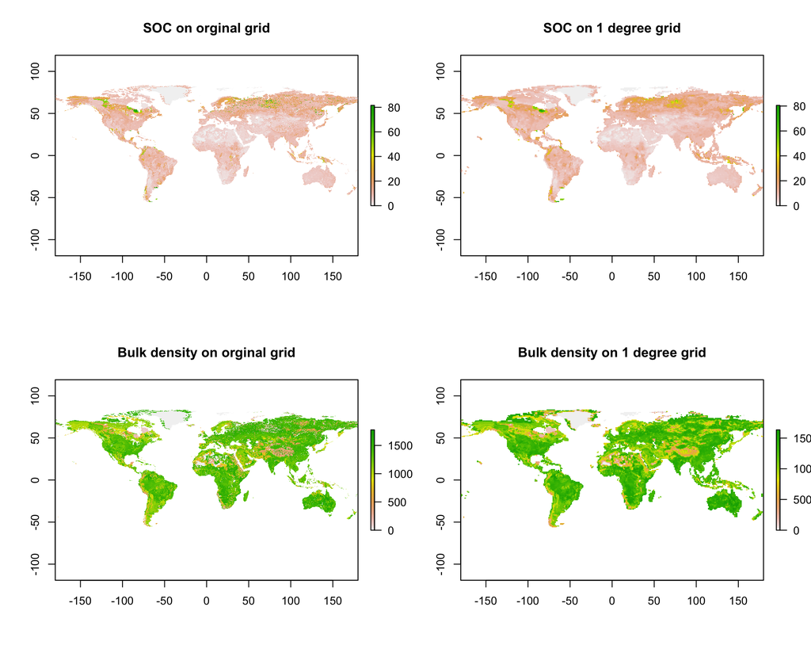

```r
par(mfrow=c(2,2))
plot(soc, main='SOC on orginal grid')
plot(soc.regrid, main='SOC on 1 degree grid')
plot(bulk, main='Bulk density on orginal grid')
plot(bulk.regrid, main='Bulk density on 1 degree grid')
```